# Logistic models

# 2019-01-09

It made sense to transfer the logistic analysis to here since it’s mostly in R.

## inattention, volume

```r
library(gdata)
library(nnet)
load('~/data/baseline_prediction/combined_descriptives_12172018.RData.gz')
clin = read.csv('~/data/baseline_prediction/long_clin_11302018.csv')
df = merge(clin, data, by='MRN')
idx = df$diag_group != 'new_onset'
idx2 = !is.na(df$inatt_vol_lh) | !is.na(df$inatt_AD_clu1) | !is.na(df$inatt_melodic_DMN)
imaging = df[idx & idx2,]
imaging[imaging$OLS_inatt_slope <= -.33, 'OLS_inatt_categ'] = 'marked'
imaging[imaging$OLS_inatt_slope > -.33 & imaging$OLS_inatt_slope <= 0, 'OLS_inatt_categ'] = 'mild'
imaging[imaging$OLS_inatt_slope > 0, 'OLS_inatt_categ'] = 'deter'
imaging[imaging$DX == 'NV', 'OLS_inatt_categ'] = 'NV'
imaging$OLS_inatt_categ = as.factor(imaging$OLS_inatt_categ)
imaging$OLS_inatt_categ = relevel(imaging$OLS_inatt_categ, ref='NV')
load('~/data/baseline_prediction/combined_descriptives_12172018.RData.gz')
clin = read.csv('~/data/baseline_prediction/long_clin_11302018.csv')
df = merge(clin, data, by='MRN')
idx = df$diag_group != 'new_onset'
struct = df[!is.na(df$HI_vol_rh) & idx,]
load('~/data/baseline_prediction/struct_volume_11142018_260timeDiff12mo.RData.gz')
struct = merge(struct, data, by='MRN') # put mask ids in combined dataset
mprage = read.xls('~/data/baseline_prediction/long_scans_08072018.xlsx',
                  sheet='mprage')
struct = merge(struct, mprage, by.x='mask.id', by.y='Mask.ID...Scan') # get demographics
qc = read.csv('~/data/baseline_prediction/master_qc.csv')
struct = merge(struct, qc, by.x='mask.id', by.y='Mask.ID') # get QC scores
df = merge(struct, imaging, by='MRN')
dim(df)
```

```
[1]  241 5244
```

Now, let’s compare the simplest of models with the same one we used to get the clusters, a bit more complicated:

```r
fit1 <- multinom(OLS_inatt_categ ~ scale(inatt_vol_lh.x) + age_at_scan + I(age_at_scan^2) + Sex...Subjects + ext_avg_freesurfer5.3 + int_avg_freesurfer5.3 + mprage_QC, data = df, na.action=na.omit)
z1 <- summary(fit1)$coefficients/summary(fit1)$standard.errors
p1 <- (1 - pnorm(abs(z1), 0, 1)) * 2
rr1 = exp(coef(fit1))
pp1 = fitted(fit1)
fit2 <- multinom(OLS_inatt_categ ~ scale(inatt_vol_lh.x), data = df, na.action=na.omit)
z2 <- summary(fit2)$coefficients/summary(fit2)$standard.errors
p2 <- (1 - pnorm(abs(z2), 0, 1)) * 2
rr2 = exp(coef(fit2))
pp2 = fitted(fit2)
print(p1)
```

```
       (Intercept) scale(inatt_vol_lh.x) age_at_scan I(age_at_scan^2) Sex...SubjectsMale ext_avg_freesurfer5.3
deter  0.022533183            0.04738121  0.41395270       0.24891252        0.002623146             0.1023966
marked 0.337080723            0.02818612  0.93171828       0.89479522        0.494204426             0.8607885
mild   0.006545162            0.60732068  0.05893088       0.06125219        0.101269117             0.6581011
       int_avg_freesurfer5.3 mprage_QC
deter             0.01002034 0.7713876
marked            0.27814406 0.4239574
mild              0.12028105 0.8247601
```

```r
print(p2)
```

```
        (Intercept) scale(inatt_vol_lh.x)
deter  8.712702e-04            0.09716676
marked 9.768048e-06            0.01820195
mild   2.037821e-07            0.94229659
```

```r
print(fit1)
```

```
Call:
multinom(formula = OLS_inatt_categ ~ scale(inatt_vol_lh.x) +
    age_at_scan + I(age_at_scan^2) + Sex...Subjects + ext_avg_freesurfer5.3 +
    int_avg_freesurfer5.3 + mprage_QC, data = df, na.action = na.omit)

Coefficients:
       (Intercept) scale(inatt_vol_lh.x) age_at_scan I(age_at_scan^2) Sex...SubjectsMale ext_avg_freesurfer5.3
deter    -6.899292            -0.4151225  0.46099773      -0.03412653          1.2462371            0.87482698
marked   -2.875338             0.4059156  0.04827447      -0.00376367          0.2702481            0.09481253
mild    -10.399575            -0.1157071  1.36308372      -0.06779776          0.7354048            0.26550164
       int_avg_freesurfer5.3  mprage_QC
deter              1.4453837 -0.1236049
marked             0.6029639  0.3579345
mild               0.9610721  0.1064069

Residual Deviance: 583.6821
AIC: 631.6821
```

```r
print(fit2)
```

```
Call:
multinom(formula = OLS_inatt_categ ~ scale(inatt_vol_lh.x), data = df,
    na.action = na.omit)

Coefficients:
       (Intercept) scale(inatt_vol_lh.x)
deter   -0.5649501           -0.30315866
marked  -0.8210424            0.41183896
mild    -1.0113611            0.01456543

Residual Deviance: 620.0299
AIC: 632.0299
```

```r
print(rr1)
```

```
        (Intercept) scale(inatt_vol_lh.x) age_at_scan I(age_at_scan^2) Sex...SubjectsMale ext_avg_freesurfer5.3
deter  1.008499e-03             0.6602594    1.585655        0.9664492           3.477234              2.398460
marked 5.639710e-02             1.5006759    1.049459        0.9962434           1.310289              1.099453
mild   3.044543e-05             0.8907361    3.908227        0.9344494           2.086326              1.304085
       int_avg_freesurfer5.3 mprage_QC
deter               4.243480  0.883729
marked              1.827527  1.430372
mild                2.614498  1.112274
```

```r
print(rr2)
```

```
       (Intercept) scale(inatt_vol_lh.x)
deter    0.5683885             0.7384819
marked   0.4399728             1.5095913
mild     0.3637236             1.0146720
```

AIC of the more complex model is slightly better, but it has many terms that are not significant for any of the conditions. Let’s scrape off anything > .1 one by one, and see if the model gets better:

```r
fit <- multinom(OLS_inatt_categ ~ scale(inatt_vol_lh.x) + age_at_scan + I(age_at_scan^2) + Sex...Subjects + int_avg_freesurfer5.3, data = df, na.action=na.omit)
z <- summary(fit)$coefficients/summary(fit)$standard.errors
p <- (1 - pnorm(abs(z), 0, 1)) * 2
rr = exp(coef(fit))
pp = fitted(fit)
print(p)
```

```
       (Intercept) scale(inatt_vol_lh.x) age_at_scan I(age_at_scan^2) Sex...SubjectsMale int_avg_freesurfer5.3
deter  0.051819699            0.03447798  0.44552792       0.29232510        0.001060536           0.004887488
marked 0.404715564            0.03039763  0.96011932       0.91086332        0.484470738           0.136182084
mild   0.007982884            0.57712954  0.06031023       0.06380006        0.094448976           0.076196413
```

```r
print(fit$AIC)
```

```
[1] 623.4545
```

This is better. What if we take it down to .05?

```r
fit <- multinom(OLS_inatt_categ ~ scale(inatt_vol_lh.x) + age_at_scan + Sex...Subjects + int_avg_freesurfer5.3, data = df, na.action=na.omit)
z <- summary(fit)$coefficients/summary(fit)$standard.errors
p <- (1 - pnorm(abs(z), 0, 1)) * 2
rr = exp(coef(fit))
pp = fitted(fit)
print(p)
```

```
       (Intercept) scale(inatt_vol_lh.x) age_at_scan Sex...SubjectsMale int_avg_freesurfer5.3
deter   0.03417790            0.05139638  0.03507512        0.001082482           0.005018905
marked  0.12516582            0.02396138  0.60859949        0.488261586           0.138102813
mild    0.01389324            0.85291117  0.81690936        0.095818351           0.080214254
```

```r
print(fit$AIC)
```

```
[1] 622.075
```

I wanted to keep at least one age terms. Also, it looks weird to include just internal QC, and ideally we have already eliminated all bad scans, so let’s see what happens if we remove that.

```r
fit <- multinom(OLS_inatt_categ ~ scale(inatt_vol_lh.x) + Sex...Subjects, data = df, na.action=na.omit)
z <- summary(fit)$coefficients/summary(fit)$standard.errors
p <- (1 - pnorm(abs(z), 0, 1)) * 2
pp = fitted(fit)
print(p)
```

```
        (Intercept) scale(inatt_vol_lh.x) Sex...SubjectsMale
deter  2.044054e-05            0.01752835        0.001227767
marked 1.573282e-03            0.03542537        0.543345916
mild   5.089723e-05            0.71917032        0.115643570
```

```r
print(fit$AIC)
```

```
[1] 625.7758
```

Not really. So, the best model actually has age, sex, and freesurfer QC in it. What are the metrics to consider then?

```r
fit <- multinom(OLS_inatt_categ ~ scale(inatt_vol_lh.x) + age_at_scan + Sex...Subjects + int_avg_freesurfer5.3, data = df, na.action=na.omit)
z <- summary(fit)$coefficients/summary(fit)$standard.errors
p <- (1 - pnorm(abs(z), 0, 1)) * 2
rr = exp(coef(fit))
pp = fitted(fit)
print('p-values')
```

```
[1] "p-values"
```

```r
print(p)
```

```
       (Intercept) scale(inatt_vol_lh.x) age_at_scan Sex...SubjectsMale int_avg_freesurfer5.3
deter   0.03417790            0.05139638  0.03507512        0.001082482           0.005018905
marked  0.12516582            0.02396138  0.60859949        0.488261586           0.138102813
mild    0.01389324            0.85291117  0.81690936        0.095818351           0.080214254
```

```r
print(fit)
```

```
Call:
multinom(formula = OLS_inatt_categ ~ scale(inatt_vol_lh.x) +
    age_at_scan + Sex...Subjects + int_avg_freesurfer5.3, data = df,
    na.action = na.omit)

Coefficients:
       (Intercept) scale(inatt_vol_lh.x) age_at_scan Sex...SubjectsMale int_avg_freesurfer5.3
deter    -2.747522           -0.39318394 -0.17227691          1.3410193             1.4617196
marked   -2.015777            0.41139252 -0.04200772          0.2726724             0.7676327
mild     -3.536257           -0.03986024  0.01952421          0.7373896             1.0048827

Residual Deviance: 592.075
AIC: 622.075
```

```r
print('risk ratio')
```

```
[1] "risk ratio"
```

```r
print(rr)
```

```
       (Intercept) scale(inatt_vol_lh.x) age_at_scan Sex...SubjectsMale int_avg_freesurfer5.3
deter   0.06408645             0.6749046   0.8417461           3.822938              4.313370
marked  0.13321681             1.5089175   0.9588624           1.313470              2.154659
mild    0.02912214             0.9609237   1.0197160           2.090472              2.731587
```

Now, let’s interpret it:

- A one-unit increase in the volume of the left hemisphere cluster variable (i.e. increase by 1 SD) is associated with a decrease in the log odds of deteriorating (vs normals) in the amount of .39. That one-unit increase is also associated with a .41 increase in the log odds of a marked improvement, and .04 decrease in the log odds of mild improvement. However, only the marked improvement category in this sbest model was significant at p < .05, but deterioration was approach it.
- In terms of relative risk ratio, a one-unit increase in the the volume of that brain cluster yields a relative risk ratio of .67 of deterioration (vs normals). The relative risk ratio for a one-unit increase is 1.51 for marked improvement, and .96 for mild improvement. In other words, the odds of marked improvement, compared to normals, is 1.5 times higher for every 1 SD we increase in that brain region.

Let’s make a much simpler (but not too far off) model, and look at probabilities:

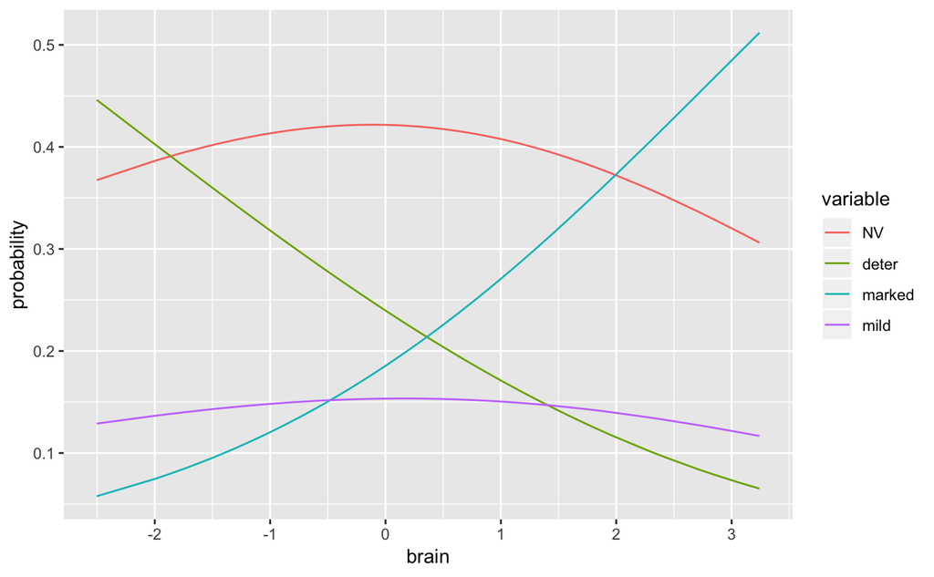

```r
library(reshape2)
library(ggplot2)
fit <- multinom(OLS_inatt_categ ~ scale(inatt_vol_lh.x), data = df, na.action=na.omit)
z <- summary(fit)$coefficients/summary(fit)$standard.errors
p <- (1 - pnorm(abs(z), 0, 1)) * 2
pp = fitted(fit)
a = cbind(pp, scale(df$inatt_vol_lh.x))
colnames(a)[5] = 'brain'
lpp = melt(as.data.frame(a), value.name='probability', id.vars=c('brain'))
ggplot(lpp, aes(x=brain, y=probability, color=variable)) + geom_line()
```

```r
print(p)
```

```
        (Intercept) scale(inatt_vol_lh.x)
deter  8.712702e-04            0.09716676
marked 9.768048e-06            0.01820195
mild   2.037821e-07            0.94229659
```

```r
print(fit$AIC)
```

```
[1] 632.0299
```

## HI, volume

We repeat the same strategy but now for the relationship between volume and HI:

```r
imaging$OLS_HI_categ = NULL
imaging[imaging$OLS_HI_slope <= -.5, 'OLS_HI_categ'] = 'marked'
imaging[imaging$OLS_HI_slope > -.5 & imaging$OLS_HI_slope <= 0, 'OLS_HI_categ'] = 'mild'
imaging[imaging$OLS_HI_slope > 0, 'OLS_HI_categ'] = 'deter'
imaging[imaging$DX == 'NV', 'OLS_HI_categ'] = 'NV'
imaging$OLS_HI_categ = as.factor(imaging$OLS_HI_categ)
imaging$OLS_HI_categ = relevel(imaging$OLS_HI_categ, ref='NV')
df = merge(struct, imaging, by='MRN')
fit1 <- multinom(OLS_HI_categ ~ scale(HI_vol_rh.x) + age_at_scan + I(age_at_scan^2) + Sex...Subjects + ext_avg_freesurfer5.3 + int_avg_freesurfer5.3 + mprage_QC, data = df, na.action=na.omit)
z1 <- summary(fit1)$coefficients/summary(fit1)$standard.errors
p1 <- (1 - pnorm(abs(z1), 0, 1)) * 2
rr1 = exp(coef(fit1))
pp1 = fitted(fit1)
fit2 <- multinom(OLS_HI_categ ~ scale(HI_vol_rh.x), data = df, na.action=na.omit)
z2 <- summary(fit2)$coefficients/summary(fit2)$standard.errors
p2 <- (1 - pnorm(abs(z2), 0, 1)) * 2
rr2 = exp(coef(fit2))
pp2 = fitted(fit2)
print(p1)
```

```
       (Intercept) scale(HI_vol_rh.x) age_at_scan I(age_at_scan^2) Sex...SubjectsMale ext_avg_freesurfer5.3
deter  0.929363618         0.00867258  0.24743345       0.34020777         0.40483322             0.5035384
marked 0.003746574         0.02985711  0.02037663       0.01545818         0.01897440             0.5291822
mild   0.013316623         0.91240011  0.51851883       0.45708648         0.03006373             0.1251160
       int_avg_freesurfer5.3 mprage_QC
deter            0.068106748 0.2846057
marked           0.250179012 0.4116816
mild             0.006037965 0.8759098
```

```r
print(p2)
```

```
        (Intercept) scale(HI_vol_rh.x)
deter  1.604686e-09        0.006670797
marked 2.331720e-02        0.034089276
mild   2.038221e-06        0.794286364
```

```r
print(fit1$AIC)
```

```
[1] 610.137
```

```r
print(fit2$AIC)
```

```
[1] 610.681
```

Very small AIC difference. Let’s see if we can remove some variables that don’t seem to contribute much:

```r
fit <- multinom(OLS_HI_categ ~ scale(HI_vol_rh.x) + age_at_scan + I(age_at_scan^2) + Sex...Subjects + int_avg_freesurfer5.3, data = df, na.action=na.omit)
z <- summary(fit)$coefficients/summary(fit)$standard.errors
p <- (1 - pnorm(abs(z), 0, 1)) * 2
print(p)
```

```
       (Intercept) scale(HI_vol_rh.x) age_at_scan I(age_at_scan^2) Sex...SubjectsMale int_avg_freesurfer5.3
deter  0.894534452        0.006585559  0.27335167        0.3414143         0.37819487            0.09501807
marked 0.006172929        0.023970083  0.02383987        0.0182074         0.01740045            0.10845036
mild   0.035879037        0.878897574  0.55171862        0.5045209         0.02288774            0.00153835
```

```r
print(fit$AIC)
```

```
[1] 603.2723
```

This is actually a much better fit. So, what does it mean?

```r
rr = exp(coef(fit))
print('p-values')
```

```
[1] "p-values"
```

```r
print(p)
```

```
       (Intercept) scale(HI_vol_rh.x) age_at_scan I(age_at_scan^2) Sex...SubjectsMale int_avg_freesurfer5.3
deter  0.894534452        0.006585559  0.27335167        0.3414143         0.37819487            0.09501807
marked 0.006172929        0.023970083  0.02383987        0.0182074         0.01740045            0.10845036
mild   0.035879037        0.878897574  0.55171862        0.5045209         0.02288774            0.00153835
```

```r
print(fit)
```

```
Call:
multinom(formula = OLS_HI_categ ~ scale(HI_vol_rh.x) + age_at_scan +
    I(age_at_scan^2) + Sex...Subjects + int_avg_freesurfer5.3,
    data = df, na.action = na.omit)

Coefficients:
       (Intercept) scale(HI_vol_rh.x) age_at_scan I(age_at_scan^2) Sex...SubjectsMale int_avg_freesurfer5.3
deter   -0.4050223         0.55395126  -0.6474144       0.02826058          0.4317837             1.1130342
marked  -8.0554774        -0.44965227   1.3333323      -0.07324785          0.8370513             0.7552926
mild    -6.5192167         0.03242992   0.3582177      -0.02048851          1.0180303             1.8351843

Residual Deviance: 567.2723
AIC: 603.2723
```

```r
print('risk ratio')
```

```
[1] "risk ratio"
```

```r
print(rr)
```

```
        (Intercept) scale(HI_vol_rh.x) age_at_scan I(age_at_scan^2) Sex...SubjectsMale int_avg_freesurfer5.3
deter  0.6669619099          1.7401151   0.5233973        1.0286637           1.540002              3.043579
marked 0.0003173588          0.6378499   3.7936641        0.9293705           2.309547              2.128234
mild   0.0014748239          1.0329615   1.4307771        0.9797200           2.767738              6.266289
```

Let’s make a much simpler (but not too far off) model, and look at probabilities:

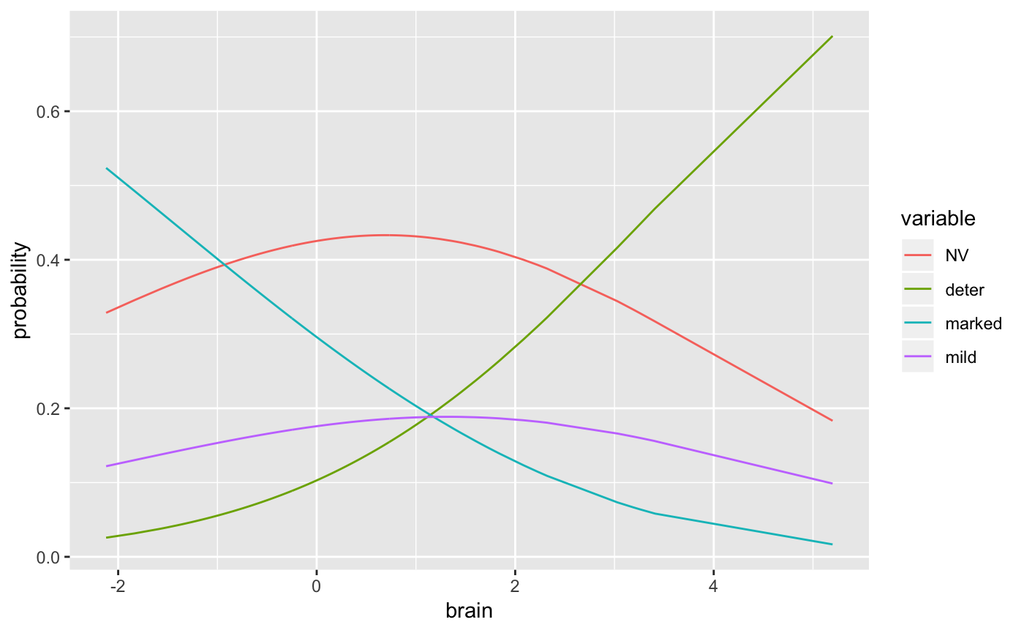

```r
library(reshape2)
library(ggplot2)
fit <- multinom(OLS_HI_categ ~ scale(HI_vol_rh.x), data = df, na.action=na.omit)
z <- summary(fit)$coefficients/summary(fit)$standard.errors
p <- (1 - pnorm(abs(z), 0, 1)) * 2
pp = fitted(fit)
a = cbind(pp, scale(df$HI_vol_rh.x))
colnames(a)[5] = 'brain'
lpp = melt(as.data.frame(a), value.name='probability', id.vars=c('brain'))
ggplot(lpp, aes(x=brain, y=probability, color=variable)) + geom_line()
```

```r
print(p)
```

```
        (Intercept) scale(HI_vol_rh.x)
deter  1.604686e-09        0.006670797
marked 2.331720e-02        0.034089276
mild   2.038221e-06        0.794286364
```

```r
print(fit$AIC)
```

```
[1] 610.681
```

## inattention, DTI

```r
load('~/data/baseline_prediction/combined_descriptives_12172018.RData.gz')
clin = read.csv('~/data/baseline_prediction/long_clin_11302018.csv')
df = merge(clin, data, by='MRN')
idx = df$diag_group != 'new_onset'
dti = df[!is.na(df$inatt_AD_clu1) & idx,]
load('~/data/baseline_prediction/dti_rd_voxelwise_n272_09212018.RData.gz')
dti = merge(dti, data, by='MRN') # put mask ids in combined dataset
mprage = read.xls('~/data/baseline_prediction/long_scans_08072018.xlsx',
                  sheet='dti')
dti = merge(dti, mprage, by.x='mask.id', by.y='Mask.ID') # get demographics
qc = read.csv('~/data/baseline_prediction/master_qc.csv')
dti = merge(dti, qc, by.x='mask.id', by.y='Mask.ID') # get QC scores
df = merge(dti, imaging, by='MRN')
df$mvmt = rowMeans(scale(df$norm.trans), scale(df$norm.rot))
dim(df)
```

```
[1]   253 12111
```

Now, let’s compare the simplest of models with the same one we used to get the clusters, a bit more complicated:

```r
fit1 <- multinom(OLS_inatt_categ ~ scale(inatt_AD_clu1.x) + scale(inatt_AD_clu2.x) + Sex + mvmt + I(mvmt^2) + age_at_scan + I(age_at_scan^2), data = df, na.action=na.omit)
z1 <- summary(fit1)$coefficients/summary(fit1)$standard.errors
p1 <- (1 - pnorm(abs(z1), 0, 1)) * 2
rr1 = exp(coef(fit1))
pp1 = fitted(fit1)
fit2 <- multinom(OLS_inatt_categ ~ scale(inatt_AD_clu1.x) + scale(inatt_AD_clu2.x), data = df, na.action=na.omit)
z2 <- summary(fit2)$coefficients/summary(fit2)$standard.errors
p2 <- (1 - pnorm(abs(z2), 0, 1)) * 2
rr2 = exp(coef(fit2))
pp2 = fitted(fit2)
print(p1)
```

```
       (Intercept) scale(inatt_AD_clu1.x) scale(inatt_AD_clu2.x)     SexMale      mvmt  I(mvmt^2) age_at_scan I(age_at_scan^2)
deter   0.28472580            0.008095507              0.1878796 0.007871372 0.2726518 0.07436325  0.37177265       0.16602924
marked  0.08650760            0.644848231              0.5010362 0.528809755 0.8243247 0.65508101  0.16644291       0.16234358
mild    0.03039555            0.246522879              0.3852470 0.129068464 0.6533751 0.74025054  0.08032727       0.07010856
```

```r
print(p2)
```

```
        (Intercept) scale(inatt_AD_clu1.x) scale(inatt_AD_clu2.x)
deter  7.936968e-04              0.1551285              0.4046382
marked 1.508324e-04              0.4099363              0.4259888
mild   7.625481e-08              0.5028259              0.4749877
```

```r
print(fit1)
```

```
Call:
multinom(formula = OLS_inatt_categ ~ scale(inatt_AD_clu1.x) +
    scale(inatt_AD_clu2.x) + Sex + mvmt + I(mvmt^2) + age_at_scan +
    I(age_at_scan^2), data = df, na.action = na.omit)

Coefficients:
       (Intercept) scale(inatt_AD_clu1.x) scale(inatt_AD_clu2.x)   SexMale        mvmt  I(mvmt^2) age_at_scan I(age_at_scan^2)
deter    -2.453636            -0.49760466             -0.2406824 1.0610269 -0.34024733 0.29284843   0.4673608      -0.04044742
marked   -3.830994             0.08802161              0.1108857 0.2314275 -0.06891239 0.07643599   0.6547195      -0.03366564
mild     -6.330239            -0.24876312             -0.1844171 0.6694241 -0.16178589 0.06813838   1.0732446      -0.05672463

Residual Deviance: 626.2736
AIC: 674.2736
```

```r
print(fit2)
```

```
Call:
multinom(formula = OLS_inatt_categ ~ scale(inatt_AD_clu1.x) +
    scale(inatt_AD_clu2.x), data = df, na.action = na.omit)

Coefficients:
       (Intercept) scale(inatt_AD_clu1.x) scale(inatt_AD_clu2.x)
deter   -0.5547607             -0.2336940             -0.1420894
marked  -0.6470321              0.1437249              0.1292934
mild    -1.0513156             -0.1311017             -0.1461257

Residual Deviance: 658.7918
AIC: 676.7918
```

```r
print(rr1)
```

```
       (Intercept) scale(inatt_AD_clu1.x) scale(inatt_AD_clu2.x)  SexMale      mvmt I(mvmt^2) age_at_scan I(age_at_scan^2)
deter  0.085980366              0.6079853              0.7860913 2.889337 0.7115943  1.340240    1.595777        0.9603597
marked 0.021688044              1.0920117              1.1172671 1.260398 0.9334085  1.079433    1.924603        0.9668947
mild   0.001781607              0.7797647              0.8315889 1.953112 0.8506233  1.070513    2.924854        0.9448542
```

```r
print(rr2)
```

```
       (Intercept) scale(inatt_AD_clu1.x) scale(inatt_AD_clu2.x)
deter    0.5742096              0.7916040              0.8675437
marked   0.5235975              1.1545664              1.1380240
mild     0.3494777              0.8771286              0.8640491
```

The more complex model does slightly better. Let’s see if removing some of the unrelated variables does anything:

```r
fit <- multinom(OLS_inatt_categ ~ scale(inatt_AD_clu1.x) + Sex + age_at_scan, data = df, na.action=na.omit)
z <- summary(fit)$coefficients/summary(fit)$standard.errors
p <- (1 - pnorm(abs(z), 0, 1)) * 2
pp = fitted(fit)
print(p)
```

```
       (Intercept) scale(inatt_AD_clu1.x)     SexMale age_at_scan
deter    0.1707157             0.01230515 0.006975043  0.00115433
marked   0.2933379             0.51541335 0.432824938  0.93563796
mild     0.1324223             0.31433432 0.141731639  0.78671670
```

```r
print(fit$AIC)
```

```
[1] 664.0228
```

This model is a bit simpler, and does better than the more complex one. Also interesting that one of the DTI clusters was a bit useless. But let’s look at the coefficients for this model:

```r
rr = exp(coef(fit))
print('p-values')
```

```
[1] "p-values"
```

```r
print(p)
```

```
       (Intercept) scale(inatt_AD_clu1.x)     SexMale age_at_scan
deter    0.1707157             0.01230515 0.006975043  0.00115433
marked   0.2933379             0.51541335 0.432824938  0.93563796
mild     0.1324223             0.31433432 0.141731639  0.78671670
```

```r
print(fit)
```

```
Call:
multinom(formula = OLS_inatt_categ ~ scale(inatt_AD_clu1.x) +
    Sex + age_at_scan, data = df, na.action = na.omit)

Coefficients:
       (Intercept) scale(inatt_AD_clu1.x)   SexMale  age_at_scan
deter    1.0269398             -0.4491341 1.0470431 -0.270052592
marked  -0.7560575              0.1200933 0.2811194 -0.006013174
mild    -1.2555280             -0.2086981 0.6331315 -0.022928542

Residual Deviance: 640.0228
AIC: 664.0228
```

```r
print('risk ratio')
```

```
[1] "risk ratio"
```

```r
print(rr)
```

```
       (Intercept) scale(inatt_AD_clu1.x)  SexMale age_at_scan
deter    2.7925070              0.6381805 2.849214   0.7633393
marked   0.4695138              1.1276020 1.324612   0.9940049
mild     0.2849254              0.8116402 1.883500   0.9773323
```

Let’s make a much simpler (but not too far off) model, and look at probabilities:

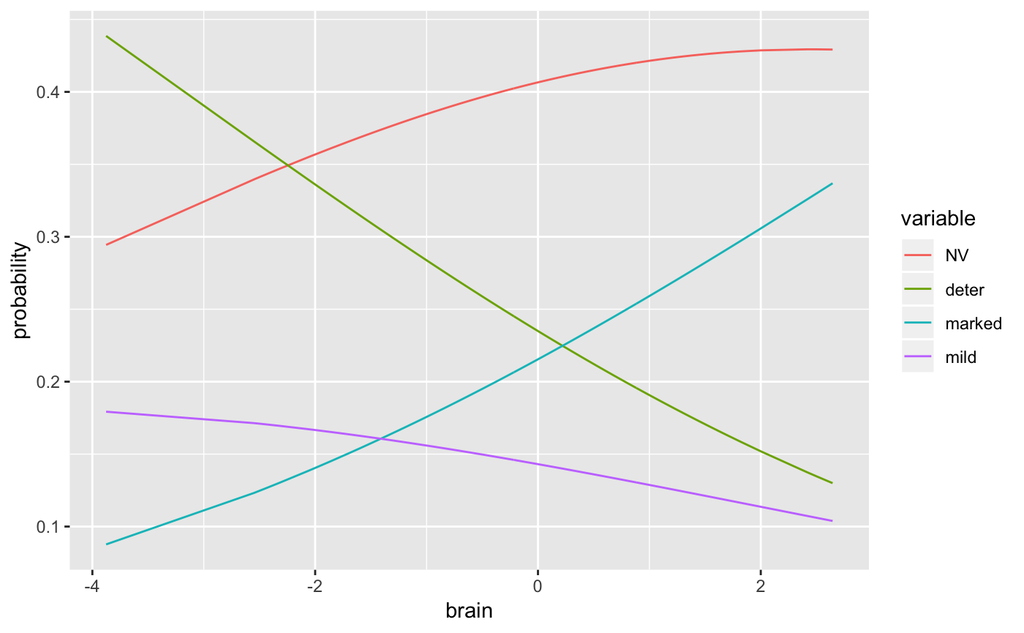

```r
library(reshape2)
library(ggplot2)
fit <- multinom(OLS_inatt_categ ~ scale(inatt_AD_clu1.x), data = df, na.action=na.omit)
z <- summary(fit)$coefficients/summary(fit)$standard.errors
p <- (1 - pnorm(abs(z), 0, 1)) * 2
pp = fitted(fit)
a = cbind(pp, scale(df$inatt_AD_clu1.x))
colnames(a)[5] = 'brain'
lpp = melt(as.data.frame(a), value.name='probability', id.vars=c('brain'))
ggplot(lpp, aes(x=brain, y=probability, color=variable)) + geom_line()
```

```r
print(p)
```

```
        (Intercept) scale(inatt_AD_clu1.x)
deter  8.659209e-04              0.1352950
marked 1.776564e-04              0.3921643
mild   7.883483e-08              0.4679238
```

```r
print(fit$AIC)
```

```
[1] 673.4222
```

## HI, DTI

```r
fit1 <- multinom(OLS_HI_categ ~ scale(HI_RD_clu1.x) + Sex + mvmt + I(mvmt^2) + age_at_scan + I(age_at_scan^2), data = df, na.action=na.omit)
z1 <- summary(fit1)$coefficients/summary(fit1)$standard.errors
p1 <- (1 - pnorm(abs(z1), 0, 1)) * 2
rr1 = exp(coef(fit1))
pp1 = fitted(fit1)
fit2 <- multinom(OLS_HI_categ ~ scale(HI_RD_clu1.x), data = df, na.action=na.omit)
z2 <- summary(fit2)$coefficients/summary(fit2)$standard.errors
p2 <- (1 - pnorm(abs(z2), 0, 1)) * 2
rr2 = exp(coef(fit2))
pp2 = fitted(fit2)
print(p1)
```

```
       (Intercept) scale(HI_RD_clu1.x)    SexMale      mvmt I(mvmt^2) age_at_scan I(age_at_scan^2)
deter   0.69549226          0.43876080 0.46798610 0.3641950 0.6551462  0.89745807       0.92615914
marked  0.08018932          0.42429355 0.13650481 0.5286846 0.2850560  0.07712120       0.03824558
mild    0.00809857          0.05183655 0.06547435 0.1576633 0.1144169  0.04084117       0.04672020
```

```r
print(p2)
```

```
        (Intercept) scale(HI_RD_clu1.x)
deter  1.047996e-08           0.2171421
marked 5.832491e-02           0.6576175
mild   1.076369e-06           0.1336489
```

```r
print(fit1)
```

```
Call:
multinom(formula = OLS_HI_categ ~ scale(HI_RD_clu1.x) + Sex +
    mvmt + I(mvmt^2) + age_at_scan + I(age_at_scan^2), data = df,
    na.action = na.omit)

Coefficients:
       (Intercept) scale(HI_RD_clu1.x)   SexMale       mvmt   I(mvmt^2) age_at_scan I(age_at_scan^2)
deter   -0.9303144           0.1781620 0.3195366  0.3329632 -0.09086168 -0.06426853      0.002306087
marked  -4.0460795          -0.1378776 0.4996070 -0.1740993  0.16048844  0.90076927     -0.056817998
mild    -7.4971151           0.4326054 0.8104379 -0.4839771  0.28608295  1.20470891     -0.059505933

Residual Deviance: 620.6857
AIC: 662.6857
```

```r
print(fit2)
```

```
Call:
multinom(formula = OLS_HI_categ ~ scale(HI_RD_clu1.x), data = df,
    na.action = na.omit)

Coefficients:
       (Intercept) scale(HI_RD_clu1.x)
deter   -1.1760087          0.25249685
marked  -0.2872967         -0.06820104
mild    -0.9093761          0.27842161

Residual Deviance: 646.9869
AIC: 658.9869
```

```r
print(rr1)
```

```
        (Intercept) scale(HI_RD_clu1.x)  SexMale      mvmt I(mvmt^2) age_at_scan I(age_at_scan^2)
deter  0.3944296925           1.1950188 1.376490 1.3950959  0.913144   0.9377532        1.0023087
marked 0.0174908140           0.8712053 1.648073 0.8402134  1.174084   2.4614959        0.9447660
mild   0.0005546823           1.5412679 2.248893 0.6163273  1.331203   3.3357879        0.9422299
```

```r
print(rr2)
```

```
       (Intercept) scale(HI_RD_clu1.x)
deter    0.3085076           1.2872354
marked   0.7502891           0.9340727
mild     0.4027755           1.3210430
```

The simple model is a bit, better, but let’s see if we can play with the other terms based on their significance, and both make AIC better and also the cluster terms more significant.

```r
fit <- multinom(OLS_HI_categ ~ scale(HI_RD_clu1.x) + age_at_scan + I(age_at_scan^2), data = df, na.action=na.omit)
z <- summary(fit)$coefficients/summary(fit)$standard.errors
p <- (1 - pnorm(abs(z), 0, 1)) * 2
pp = fitted(fit)
print(p)
```

```
       (Intercept) scale(HI_RD_clu1.x) age_at_scan I(age_at_scan^2)
deter    0.6519888          0.33694333  0.99990978       0.95875456
marked   0.1001735          0.45434814  0.06199740       0.02991257
mild     0.0126411          0.04568912  0.02986371       0.03594689
```

```r
print(fit$AIC)
```

```
[1] 654.4191
```

OK, so this does a bit of both. Let’s take a look at the coefficients:

```r
rr = exp(coef(fit))
print('p-values')
```

```
[1] "p-values"
```

```r
print(p)
```

```
       (Intercept) scale(HI_RD_clu1.x) age_at_scan I(age_at_scan^2)
deter    0.6519888          0.33694333  0.99990978       0.95875456
marked   0.1001735          0.45434814  0.06199740       0.02991257
mild     0.0126411          0.04568912  0.02986371       0.03594689
```

```r
print(fit)
```

```
Call:
multinom(formula = OLS_HI_categ ~ scale(HI_RD_clu1.x) + age_at_scan +
    I(age_at_scan^2), data = df, na.action = na.omit)

Coefficients:
       (Intercept) scale(HI_RD_clu1.x)   age_at_scan I(age_at_scan^2)
deter    -1.063130           0.2215117 -5.596519e-05     -0.001278242
marked   -3.729930          -0.1275482  9.369030e-01     -0.058568183
mild     -6.980719           0.4304645  1.270362e+00     -0.062275717

Residual Deviance: 630.4191
AIC: 654.4191
```

```r
print('risk ratio')
```

```
[1] "risk ratio"
```

```r
print(rr)
```

```
        (Intercept) scale(HI_RD_clu1.x) age_at_scan I(age_at_scan^2)
deter  0.3453731011            1.247962    0.999944        0.9987226
marked 0.0239945077            0.880251    2.552066        0.9431139
mild   0.0009296348            1.537972    3.562143        0.9396238
```

Now, let’s interpret it:

- This is a unique result so far as it’s only significant for the mild improvement group. Not sure how to interpret that…
- In any case, a one-unit increase in the RD of that brain cluster yields a relative risk ratio of 1.53 of mild-improvement (vs normals).

Let’s make a much simpler (but not too far off) model, and look at probabilities:

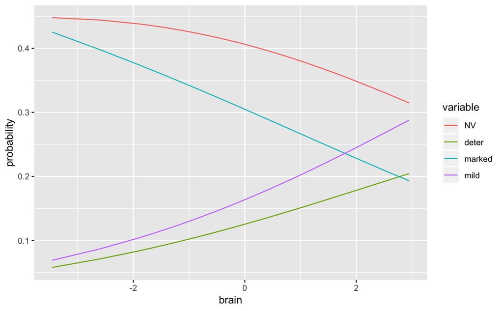

```r
library(reshape2)
library(ggplot2)
fit <- multinom(OLS_HI_categ ~ scale(HI_RD_clu1.x), data = df, na.action=na.omit)
z <- summary(fit)$coefficients/summary(fit)$standard.errors
p <- (1 - pnorm(abs(z), 0, 1)) * 2
pp = fitted(fit)
a = cbind(pp, scale(df$HI_RD_clu1.x))
colnames(a)[5] = 'brain'
lpp = melt(as.data.frame(a), value.name='probability', id.vars=c('brain'))
ggplot(lpp, aes(x=brain, y=probability, color=variable)) + geom_line()
```

```r
print(p)
```

```
        (Intercept) scale(HI_RD_clu1.x)
deter  1.047996e-08           0.2171421
marked 5.832491e-02           0.6576175
mild   1.076369e-06           0.1336489
```

```r
print(fit$AIC)
```

```
[1] 658.9869
```

## inattention, rsFMRI

```r
load('~/data/baseline_prediction/combined_descriptives_12172018.RData.gz')
clin = read.csv('~/data/baseline_prediction/long_clin_11302018.csv')
df = merge(clin, data, by='MRN')
idx = df$diag_group != 'new_onset'
fmri = df[!is.na(df$inatt_melodic_limbic) & idx,]
load('~/data/baseline_prediction/melodic_inter_IC11_12142018.RData.gz')
fmri = merge(fmri, data, by='MRN') # put mask ids in combined dataset
mprage = read.xls('~/data/baseline_prediction/long_scans_08072018.xlsx',
                  sheet='mprage')
fmri = merge(fmri, mprage, by.x='mask.id', by.y='Mask.ID...Scan') # get demographics
qc = read.csv('~/data/baseline_prediction/master_qc.csv')
fmri = merge(fmri, qc, by.x='mask.id', by.y='Mask.ID') # get QC scores
df = merge(fmri, imaging, by='MRN')
dim(df)
```

```
[1]   196 44332
```

Now, let’s compare the simplest of models with the same one we used to get the clusters, a bit more complicated:

```r
fit1 <- multinom(OLS_inatt_categ ~ scale(inatt_melodic_limbic.x) + scale(inatt_melodic_DMN.x) + scale(inatt_melodic_VAN.x) + Sex...Subjects + enormGoodTRs_fmri01 + I(enormGoodTRs_fmri01^2) + age_at_scan + I(age_at_scan^2), data = df, na.action=na.omit)
z1 <- summary(fit1)$coefficients/summary(fit1)$standard.errors
p1 <- (1 - pnorm(abs(z1), 0, 1)) * 2
rr1 = exp(coef(fit1))
pp1 = fitted(fit1)
fit2 <- multinom(OLS_inatt_categ ~ scale(inatt_melodic_limbic.x) + scale(inatt_melodic_DMN.x) + scale(inatt_melodic_VAN.x), data = df, na.action=na.omit)
z2 <- summary(fit2)$coefficients/summary(fit2)$standard.errors
p2 <- (1 - pnorm(abs(z2), 0, 1)) * 2
rr2 = exp(coef(fit2))
pp2 = fitted(fit2)
print(p1)
```

```
       (Intercept) scale(inatt_melodic_limbic.x) scale(inatt_melodic_DMN.x) scale(inatt_melodic_VAN.x) Sex...SubjectsMale
deter   0.24437858                   0.063316569                  0.5649944                0.008468946          0.3108260
marked  0.78956120                   0.005708966                  0.1160827                0.002476022          0.6433843
mild    0.01998896                   0.345342912                  0.3017331                0.999527231          0.7744917
       enormGoodTRs_fmri01 I(enormGoodTRs_fmri01^2) age_at_scan I(age_at_scan^2)
deter           0.01313451             0.0003788053  0.57691005       0.52820028
marked          0.01573310             0.0092631881  0.67050081       0.65350736
mild            0.15287833             0.6449919725  0.04551339       0.04915172
```

```r
print(p2)
```

```
        (Intercept) scale(inatt_melodic_limbic.x) scale(inatt_melodic_DMN.x) scale(inatt_melodic_VAN.x)
deter  5.139658e-06                   0.006023913                 0.58146399                0.004486532
marked 4.194975e-07                   0.013937816                 0.09028976                0.001877151
mild   7.194087e-07                   0.577532840                 0.31940027                0.905824805
```

```r
print(fit1)
```

```
Call:
multinom(formula = OLS_inatt_categ ~ scale(inatt_melodic_limbic.x) +
    scale(inatt_melodic_DMN.x) + scale(inatt_melodic_VAN.x) +
    Sex...Subjects + enormGoodTRs_fmri01 + I(enormGoodTRs_fmri01^2) +
    age_at_scan + I(age_at_scan^2), data = df, na.action = na.omit)

Coefficients:
       (Intercept) scale(inatt_melodic_limbic.x) scale(inatt_melodic_DMN.x) scale(inatt_melodic_VAN.x) Sex...SubjectsMale
deter   -4.5986328                     0.3996381                 -0.1166158              -0.6212094700          0.4498880
marked  -0.9885949                    -0.7392616                  0.3716028               0.7637967427         -0.2080921
mild   -12.8383615                    -0.2299097                  0.2418409              -0.0001508557          0.1317672
       enormGoodTRs_fmri01 I(enormGoodTRs_fmri01^2) age_at_scan I(age_at_scan^2)
deter             20.78070                 4.205177   0.4395262      -0.02420683
marked            19.17995                 2.705812  -0.3106891       0.01553532
mild              10.88764                 0.468790   2.1392109      -0.10023245

Residual Deviance: 433.2433
AIC: 487.2433
```

```r
print(fit2)
```

```
Call:
multinom(formula = OLS_inatt_categ ~ scale(inatt_melodic_limbic.x) +
    scale(inatt_melodic_DMN.x) + scale(inatt_melodic_VAN.x),
    data = df, na.action = na.omit)

Coefficients:
       (Intercept) scale(inatt_melodic_limbic.x) scale(inatt_melodic_DMN.x) scale(inatt_melodic_VAN.x)
deter    -1.050570                     0.5671990                 -0.1101917                -0.64201453
marked   -1.336101                    -0.6521674                  0.3951915                 0.77302963
mild     -1.067356                    -0.1345982                  0.2267130                 0.02821911

Residual Deviance: 447.3053
AIC: 471.3053
```

```r
print(rr1)
```

```
        (Intercept) scale(inatt_melodic_limbic.x) scale(inatt_melodic_DMN.x) scale(inatt_melodic_VAN.x) Sex...SubjectsMale
deter  1.006559e-02                     1.4912850                  0.8899271                  0.5372942          1.5681366
marked 3.720992e-01                     0.4774664                  1.4500568                  2.1464101          0.8121323
mild   2.656871e-06                     0.7946053                  1.2735916                  0.9998492          1.1408427
       enormGoodTRs_fmri01 I(enormGoodTRs_fmri01^2) age_at_scan I(age_at_scan^2)
deter         1059114946.7                67.032455   1.5519717        0.9760838
marked         213671785.6                14.966470   0.7329417        1.0156566
mild               53511.1                 1.598059   8.4927333        0.9046271
```

```r
print(rr2)
```

```
       (Intercept) scale(inatt_melodic_limbic.x) scale(inatt_melodic_DMN.x) scale(inatt_melodic_VAN.x)
deter    0.3497383                     1.7633210                  0.8956624                  0.5262312
marked   0.2628685                     0.5209155                  1.4846686                  2.1663195
mild     0.3439165                     0.8740671                  1.2544698                  1.0286210
```

The simpler module is better, but let’s see if we can trim the more complex model a bit.

```r
fit <- multinom(OLS_inatt_categ ~ scale(inatt_melodic_limbic.x) + scale(inatt_melodic_VAN.x) + enormGoodTRs_fmri01 + I(enormGoodTRs_fmri01^2) + age_at_scan + I(age_at_scan^2), data = df, na.action=na.omit)
z <- summary(fit)$coefficients/summary(fit)$standard.errors
p <- (1 - pnorm(abs(z), 0, 1)) * 2
print(p)
```

```
       (Intercept) scale(inatt_melodic_limbic.x) scale(inatt_melodic_VAN.x) enormGoodTRs_fmri01 I(enormGoodTRs_fmri01^2)
deter   0.22040190                    0.06139543                0.008228684         0.006758215             0.0006973436
marked  0.78212842                    0.00361549                0.001353688         0.010988725             0.0096054973
mild    0.02070349                    0.29458297                0.972491095         0.102164154             0.3360454001
       age_at_scan I(age_at_scan^2)
deter   0.49935456        0.4610659
marked  0.66561581        0.6779408
mild    0.04635539        0.0490705
```

```r
print(fit$AIC)
```

```
[1] 480.8971
```

# Questions

- Add pictures of where the brain regions actually are
- Should we go for mixel effects given the family structure in the data (and also used to gett he clusters)?